# Assignment 5

## 5.1 Data description

```r
library(tidyr)
library(stringr)


#read the datasets
human5 <- read.table("https://raw.githubusercontent.com/KimmoVehkalahti/Helsinki-Open-Data-Science/master/datasets/human2.txt", sep=",", header = TRUE)

#colnames
colnames(human5)
```

```
## [1] "Edu2.FM"   "Labo.FM"   "Edu.Exp"   "Life.Exp"  "GNI"       "Mat.Mor"
## [7] "Ado.Birth" "Parli.F"
```

```r
#structure
str(human5)
```

```
## 'data.frame':    155 obs. of  8 variables:
##  $ Edu2.FM  : num  1.007 0.997 0.983 0.989 0.969 ...
##  $ Labo.FM  : num  0.891 0.819 0.825 0.884 0.829 ...
##  $ Edu.Exp  : num  17.5 20.2 15.8 18.7 17.9 16.5 18.6 16.5 15.9 19.2 ...
##  $ Life.Exp : num  81.6 82.4 83 80.2 81.6 80.9 80.9 79.1 82 81.8 ...
##  $ GNI      : int  64992 42261 56431 44025 45435 43919 39568 52947 42155 32689 ...
##  $ Mat.Mor  : int  4 6 6 5 6 7 9 28 11 8 ...
##  $ Ado.Birth: num  7.8 12.1 1.9 5.1 6.2 3.8 8.2 31 14.5 25.3 ...
##  $ Parli.F  : num  39.6 30.5 28.5 38 36.9 36.9 19.9 19.4 28.2 31.4 ...
```

```r
#summary
summary(human5)
```

```
##     Edu2.FM          Labo.FM          Edu.Exp         Life.Exp
##  Min.   :0.1717   Min.   :0.1857   Min.   : 5.40   Min.   :49.00
##  1st Qu.:0.7264   1st Qu.:0.5984   1st Qu.:11.25   1st Qu.:66.30
##  Median :0.9375   Median :0.7535   Median :13.50   Median :74.20
##  Mean   :0.8529   Mean   :0.7074   Mean   :13.18   Mean   :71.65
##  3rd Qu.:0.9968   3rd Qu.:0.8535   3rd Qu.:15.20   3rd Qu.:77.25
##  Max.   :1.4967   Max.   :1.0380   Max.   :20.20   Max.   :83.50
##       GNI            Mat.Mor         Ado.Birth         Parli.F
##  Min.   :   581   Min.   :   1.0   Min.   :  0.60   Min.   : 0.00
##  1st Qu.:  4198   1st Qu.:  11.5   1st Qu.: 12.65   1st Qu.:12.40
##  Median : 12040   Median :  49.0   Median : 33.60   Median :19.30
##  Mean   : 17628   Mean   : 149.1   Mean   : 47.16   Mean   :20.91
##  3rd Qu.: 24512   3rd Qu.: 190.0   3rd Qu.: 71.95   3rd Qu.:27.95
##  Max.   :123124   Max.   :1100.0   Max.   :204.80   Max.   :57.50
```

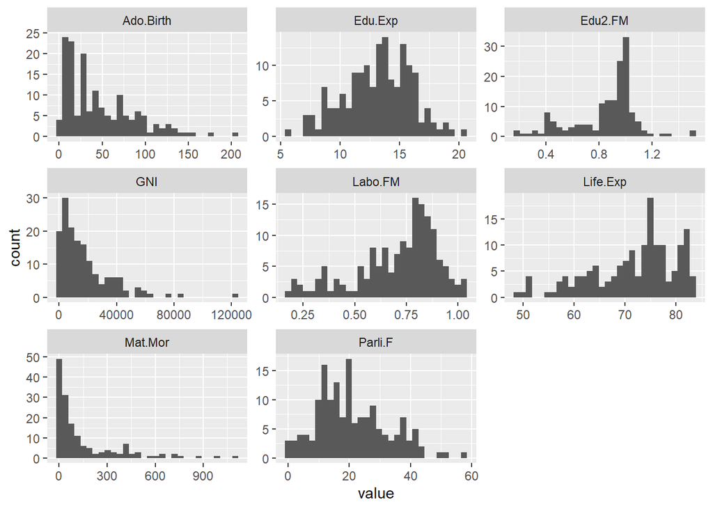

```r
#distributions of variables and graphical overview
# visualize the dataset
library(ggplot2)
pivot_longer(human5, cols = everything()) %>%
  ggplot(aes(value)) + facet_wrap("name", scales = "free") + geom_histogram(bins = 30)
```

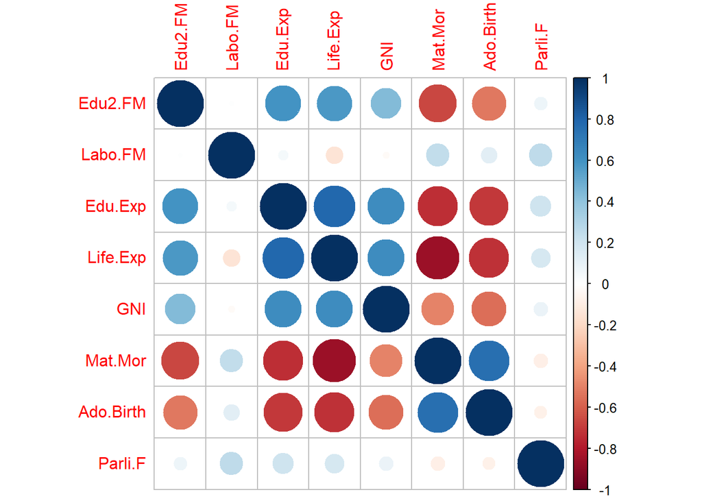

```r
#relationships between variables
library(corrplot)
# compute the correlation matrix and visualize it with corrplot
cor(human5) %>% corrplot()
```

```r
cor(human5)
```

```
##                Edu2.FM      Labo.FM     Edu.Exp   Life.Exp         GNI
## Edu2.FM    1.000000000  0.009564039  0.59325156  0.5760299  0.43030485
## Labo.FM    0.009564039  1.000000000  0.04732183 -0.1400125 -0.02173971
## Edu.Exp    0.593251562  0.047321827  1.00000000  0.7894392  0.62433940
## Life.Exp   0.576029853 -0.140012504  0.78943917  1.0000000  0.62666411
## GNI        0.430304846 -0.021739705  0.62433940  0.6266641  1.00000000
## Mat.Mor   -0.660931770  0.240461075 -0.73570257 -0.8571684 -0.49516234
## Ado.Birth -0.529418415  0.120158862 -0.70356489 -0.7291774 -0.55656208
## Parli.F    0.078635285  0.250232608  0.20608156  0.1700863  0.08920818
##              Mat.Mor  Ado.Birth     Parli.F
## Edu2.FM   -0.6609318 -0.5294184  0.07863528
## Labo.FM    0.2404611  0.1201589  0.25023261
## Edu.Exp   -0.7357026 -0.7035649  0.20608156
## Life.Exp  -0.8571684 -0.7291774  0.17008631
## GNI       -0.4951623 -0.5565621  0.08920818
## Mat.Mor    1.0000000  0.7586615 -0.08944000
## Ado.Birth  0.7586615  1.0000000 -0.07087810
## Parli.F   -0.0894400 -0.0708781  1.00000000
```

The data includes 8 variables (and 155 observations): -Ado.Birth; Adolescent birth rate -Edu.Exp; Expected years of schooling -Edu2.FM; Population with Secondary Education (Female)/Population with Secondary Education (Male) -GNI; Gross National Income per capital -Labo.FM; Labour Force Participation Rate (Female)/Labour Force Participation Rate (Male) -Life.Exp; Life expectancy at birth -Mat.Mor; Maternal mortality ratio -Parli.F; Percetange of representatives in parliament

Mean of the life expectancy was 72 years and expected year of schooling 13 years.

There were on average more males in population with secondary education and in labour force.

Life expectancy, Expected years of schooling, Maternal mortality ratio (negative) and Adolescent birth rate (negative) were highly correlated.

## 5.2 Principal component analysis (PCA)

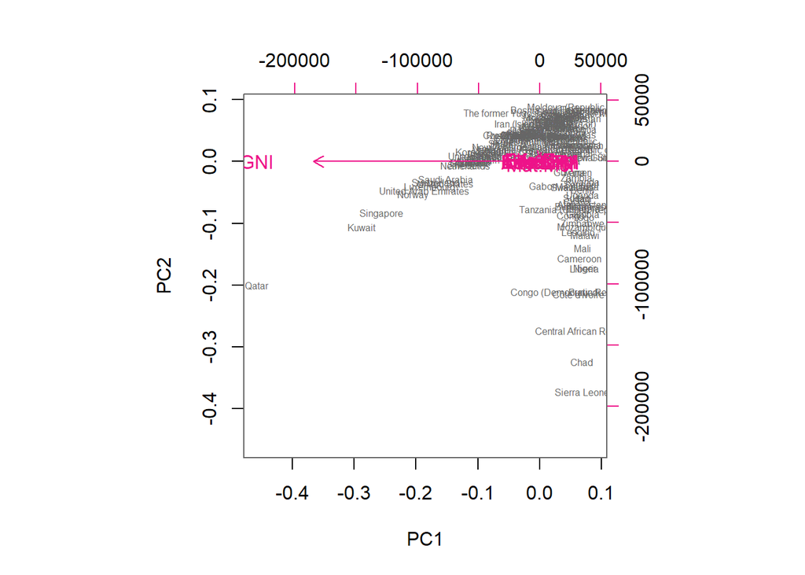

```r
#RAW data
# perform principal component analysis (with the SVD method) on the raw human data
pca_human5 <- prcomp(human5)

# draw a biplot of the principal component representation and the original variables
biplot(pca_human5, choices = 1:2, col = c("grey40", "deeppink2"), cex = c(0.5, 1))
```

```r
#standardized data
# standardize the variables
human_std <- scale(human5)

# print out summaries of the standardized variables
summary(human_std)
```

```
##     Edu2.FM           Labo.FM           Edu.Exp           Life.Exp
##  Min.   :-2.8189   Min.   :-2.6247   Min.   :-2.7378   Min.   :-2.7188
##  1st Qu.:-0.5233   1st Qu.:-0.5484   1st Qu.:-0.6782   1st Qu.:-0.6425
##  Median : 0.3503   Median : 0.2316   Median : 0.1140   Median : 0.3056
##  Mean   : 0.0000   Mean   : 0.0000   Mean   : 0.0000   Mean   : 0.0000
##  3rd Qu.: 0.5958   3rd Qu.: 0.7350   3rd Qu.: 0.7126   3rd Qu.: 0.6717
##  Max.   : 2.6646   Max.   : 1.6632   Max.   : 2.4730   Max.   : 1.4218
##       GNI             Mat.Mor          Ado.Birth          Parli.F
##  Min.   :-0.9193   Min.   :-0.6992   Min.   :-1.1325   Min.   :-1.8203
##  1st Qu.:-0.7243   1st Qu.:-0.6496   1st Qu.:-0.8394   1st Qu.:-0.7409
##  Median :-0.3013   Median :-0.4726   Median :-0.3298   Median :-0.1403
##  Mean   : 0.0000   Mean   : 0.0000   Mean   : 0.0000   Mean   : 0.0000
##  3rd Qu.: 0.3712   3rd Qu.: 0.1932   3rd Qu.: 0.6030   3rd Qu.: 0.6127
##  Max.   : 5.6890   Max.   : 4.4899   Max.   : 3.8344   Max.   : 3.1850
```

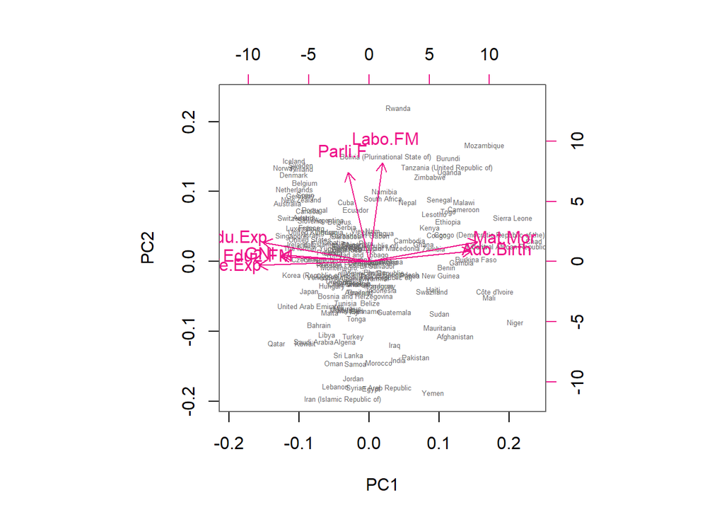

```r
# perform principal component analysis (with the SVD method)
pca_human5_std <- prcomp(human_std)

# draw a biplot of the principal component representation and the original variables
biplot(pca_human5_std, choices = 1:2, col = c("grey40", "deeppink2"), cex = c(0.4, 1))
```

Principal component analyses are presented above for raw data and standardized data. Results differed from each others, due to different scales used in outcomes. There were a lot of zero-length arrows in the raw-model, except GNI.

My personal interpretations of the first two principal component dimensions based on the biplot drawn for PCA on the standardized human data are Health and Equality.

## 5.3 Tea dataset

```r
library(dplyr)
```

```r
library(tidyr)
library(ggplot2)
tea <- read.table("https://raw.githubusercontent.com/KimmoVehkalahti/Helsinki-Open-Data-Science/master/datasets/tea.csv", sep = ",", header = T)

#structure of the data
colnames(tea)
```

```
##  [1] "breakfast"        "tea.time"         "evening"          "lunch"
##  [5] "dinner"           "always"           "home"             "work"
##  [9] "tearoom"          "friends"          "resto"            "pub"
## [13] "Tea"              "How"              "sugar"            "how"
## [17] "where"            "price"            "age"              "sex"
## [21] "SPC"              "Sport"            "age_Q"            "frequency"
## [25] "escape.exoticism" "spirituality"     "healthy"          "diuretic"
## [29] "friendliness"     "iron.absorption"  "feminine"         "sophisticated"
## [33] "slimming"         "exciting"         "relaxing"         "effect.on.health"
```

```r
View(tea)

str(tea)
```

```
## 'data.frame':    300 obs. of  36 variables:
##  $ breakfast       : chr  "breakfast" "breakfast" "Not.breakfast" "Not.breakfast" ...
##  $ tea.time        : chr  "Not.tea time" "Not.tea time" "tea time" "Not.tea time" ...
##  $ evening         : chr  "Not.evening" "Not.evening" "evening" "Not.evening" ...
##  $ lunch           : chr  "Not.lunch" "Not.lunch" "Not.lunch" "Not.lunch" ...
##  $ dinner          : chr  "Not.dinner" "Not.dinner" "dinner" "dinner" ...
##  $ always          : chr  "Not.always" "Not.always" "Not.always" "Not.always" ...
##  $ home            : chr  "home" "home" "home" "home" ...
##  $ work            : chr  "Not.work" "Not.work" "work" "Not.work" ...
##  $ tearoom         : chr  "Not.tearoom" "Not.tearoom" "Not.tearoom" "Not.tearoom" ...
##  $ friends         : chr  "Not.friends" "Not.friends" "friends" "Not.friends" ...
##  $ resto           : chr  "Not.resto" "Not.resto" "resto" "Not.resto" ...
##  $ pub             : chr  "Not.pub" "Not.pub" "Not.pub" "Not.pub" ...
##  $ Tea             : chr  "black" "black" "Earl Grey" "Earl Grey" ...
##  $ How             : chr  "alone" "milk" "alone" "alone" ...
```

[output cut: 22 more lines]

```r
#convert outcomes to factors
tea$breakfast <- factor(tea$breakfast)
tea$tea.time <- factor(tea$tea.time)
tea$evening <- factor(tea$evening)
tea$lunch <- factor(tea$lunch)
tea$dinner <- factor(tea$dinner)
tea$always <- factor(tea$always)
tea$home <- factor(tea$home)
tea$work <- factor(tea$work)
tea$tearoom <- factor(tea$tearoom)
tea$friends <- factor(tea$friends)
tea$resto <- factor(tea$resto)
tea$pub <- factor(tea$pub)
tea$Tea <- factor(tea$Tea)
tea$How <- factor(tea$How)
tea$sugar <- factor(tea$sugar)
tea$how <- factor(tea$how)
tea$sugar <- factor(tea$sugar)
tea$where <- factor(tea$where)
tea$Tea <- factor(tea$Tea)
tea$price <- factor(tea$price)
tea$sex <- factor(tea$sex)
tea$SPC <- factor(tea$SPC)
tea$Sport <- factor(tea$Sport)
tea$age_Q <- factor(tea$age_Q)
tea$frequency <- factor(tea$frequency)
tea$escape.exoticism <- factor(tea$escape.exoticism)
tea$spirituality <- factor(tea$spirituality)
tea$healthy <- factor(tea$healthy)
tea$diuretic <- factor(tea$diuretic)
tea$friendliness <- factor(tea$friendliness)
tea$iron.absorption <- factor(tea$iron.absorption)
tea$feminine <- factor(tea$feminine)
tea$sophisticated <- factor(tea$sophisticated)
tea$slimming <- factor(tea$slimming)
tea$exciting <- factor(tea$exciting)
tea$relaxing <- factor(tea$relaxing)
tea$effect.on.health <- factor(tea$effect.on.health)


library(dplyr)
library(tidyr)

colnames(tea)
```

```
##  [1] "breakfast"        "tea.time"         "evening"          "lunch"
##  [5] "dinner"           "always"           "home"             "work"
##  [9] "tearoom"          "friends"          "resto"            "pub"
## [13] "Tea"              "How"              "sugar"            "how"
## [17] "where"            "price"            "age"              "sex"
## [21] "SPC"              "Sport"            "age_Q"            "frequency"
## [25] "escape.exoticism" "spirituality"     "healthy"          "diuretic"
## [29] "friendliness"     "iron.absorption"  "feminine"         "sophisticated"
## [33] "slimming"         "exciting"         "relaxing"         "effect.on.health"
```

```r
# column names to keep in the dataset
keep_columns <- c("tea.time","evening", "lunch","dinner","always","home","work", "tearoom","friends","resto","pub","Tea",
"How","sugar","how","where","price","sex","SPC","Sport","age_Q" ,"frequency"
,"escape.exoticism","spirituality","healthy","diuretic","friendliness","iron.absorption"
,"feminine","sophisticated","slimming","exciting","relaxing","effect.on.health")

# select the 'keep_columns' to create a new dataset
tea_time <- dplyr::select(tea, keep_columns)
# look at the summaries and structure of the data
summary(tea_time)
```

```
##          tea.time          evening          lunch            dinner
##  Not.tea time:131   evening    :103   lunch    : 44   dinner    : 21
##  tea time    :169   Not.evening:197   Not.lunch:256   Not.dinner:279
##
##
##
##
##
##         always          home           work            tearoom
##  always    :103   home    :291   Not.work:213   Not.tearoom:242
##  Not.always:197   Not.home:  9   work    : 87   tearoom    : 58
##
##
##
##
##
##         friends          resto          pub             Tea         How
##  friends    :196   Not.resto:221   Not.pub:237   black    : 74   alone:195
##  Not.friends:104   resto    : 79   pub    : 63   Earl Grey:193   lemon: 33
##                                                  green    : 33   milk : 63
##                                                                  other:  9
##
##
##
##       sugar                     how                       where
##  No.sugar:155   tea bag           :170   chain store         :192
##  sugar   :145   tea bag+unpackaged: 94   chain store+tea shop: 78
##                 unpackaged        : 36   tea shop            : 30
##
##
##
##
##              price     sex               SPC               Sport       age_Q
##  p_branded      : 95   F:178   employee    :59   Not.sportsman:121   +60  :38
##  p_cheap        :  7   M:122   middle      :40   sportsman    :179   15-24:92
##  p_private label: 21           non-worker  :64                       25-34:69
##  p_unknown      : 12           other worker:20                       35-44:40
##  p_upscale      : 53           senior      :35                       45-59:61
##  p_variable     :112           student     :70
##                                workman     :12
```

[output cut: 25 more lines]

```
##  No.slimming:255   exciting   :116   No.relaxing:113
##  slimming   : 45   No.exciting:184   relaxing   :187
##
##
##
##
##
##             effect.on.health
##  effect on health   : 66
##  No.effect on health:234
##
##
##
##
##
```

```r
str(tea_time)
```

```
## 'data.frame':    300 obs. of  34 variables:
##  $ tea.time        : Factor w/ 2 levels "Not.tea time",..: 1 1 2 1 1 1 2 2 2 1 ...
##  $ evening         : Factor w/ 2 levels "evening","Not.evening": 2 2 1 2 1 2 2 1 2 1 ...
##  $ lunch           : Factor w/ 2 levels "lunch","Not.lunch": 2 2 2 2 2 2 2 2 2 2 ...
##  $ dinner          : Factor w/ 2 levels "dinner","Not.dinner": 2 2 1 1 2 1 2 2 2 2 ...
##  $ always          : Factor w/ 2 levels "always","Not.always": 2 2 2 2 1 2 2 2 2 2 ...
##  $ home            : Factor w/ 2 levels "home","Not.home": 1 1 1 1 1 1 1 1 1 1 ...
##  $ work            : Factor w/ 2 levels "Not.work","work": 1 1 2 1 1 1 1 1 1 1 ...
##  $ tearoom         : Factor w/ 2 levels "Not.tearoom",..: 1 1 1 1 1 1 1 1 1 2 ...
##  $ friends         : Factor w/ 2 levels "friends","Not.friends": 2 2 1 2 2 2 1 2 2 2 ...
##  $ resto           : Factor w/ 2 levels "Not.resto","resto": 1 1 2 1 1 1 1 1 1 1 ...
##  $ pub             : Factor w/ 2 levels "Not.pub","pub": 1 1 1 1 1 1 1 1 1 1 ...
##  $ Tea             : Factor w/ 3 levels "black","Earl Grey",..: 1 1 2 2 2 2 2 1 2 1 ...
##  $ How             : Factor w/ 4 levels "alone","lemon",..: 1 3 1 1 1 1 1 3 3 1 ...
##  $ sugar           : Factor w/ 2 levels "No.sugar","sugar": 2 1 1 2 1 1 1 1 1 1 ...
```

[output cut: 20 more lines]

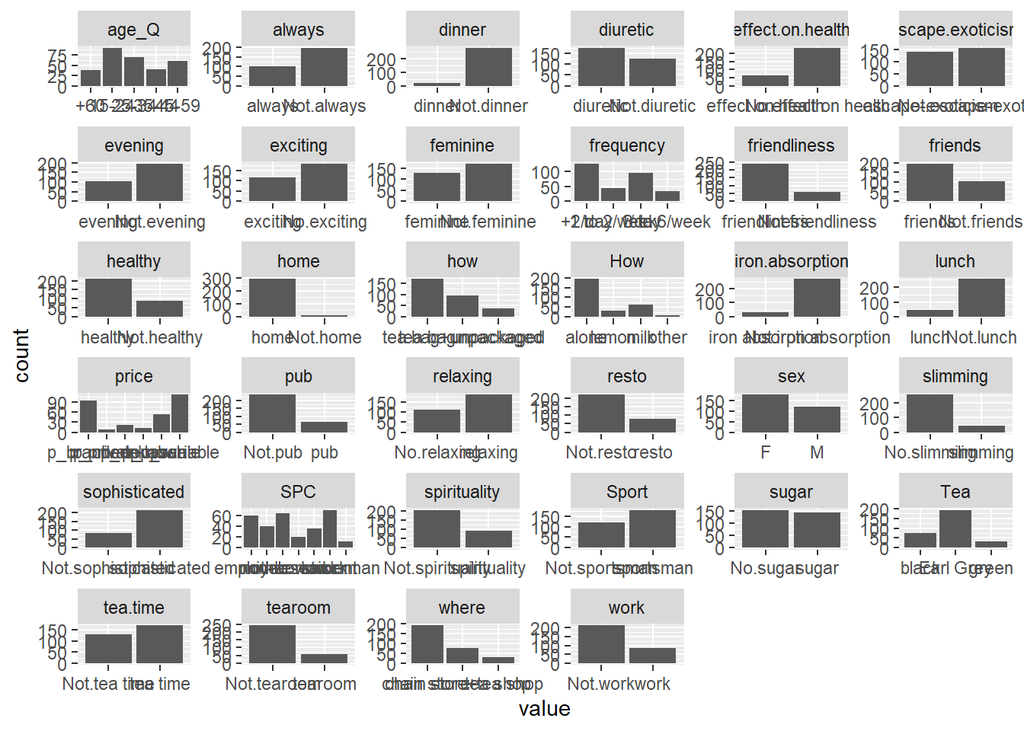

```r
# visualize the dataset
library(ggplot2)
pivot_longer(tea_time, cols = everything()) %>%
  ggplot(aes(value), theme(axis.text.x = element_text(angle = 120, hjust = 1, size = 3))) + facet_wrap("name", scales = "free") + geom_bar()
```

```r
#multiple correspondence analysis
library(FactoMineR)
```

```r
mca <- MCA(tea_time, graph = FALSE)

# summary of the model
summary(mca)
```

```
##
## Call:
## MCA(X = tea_time, graph = FALSE)
##
##
## Eigenvalues
##                        Dim.1   Dim.2   Dim.3   Dim.4   Dim.5   Dim.6   Dim.7
## Variance               0.092   0.084   0.072   0.060   0.057   0.055   0.050
## % of var.              5.913   5.392   4.629   3.881   3.672   3.502   3.188
## Cumulative % of var.   5.913  11.305  15.934  19.815  23.488  26.989  30.177
##                        Dim.8   Dim.9  Dim.10  Dim.11  Dim.12  Dim.13  Dim.14
## Variance               0.049   0.048   0.045   0.042   0.042   0.039   0.038
## % of var.              3.138   3.050   2.885   2.675   2.672   2.491   2.424
## Cumulative % of var.  33.315  36.365  39.251  41.926  44.598  47.089  49.513
##                       Dim.15  Dim.16  Dim.17  Dim.18  Dim.19  Dim.20  Dim.21
## Variance               0.036   0.036   0.034   0.032   0.032   0.031   0.030
## % of var.              2.320   2.305   2.173   2.077   2.049   2.016   1.944
## Cumulative % of var.  51.833  54.138  56.311  58.387  60.436  62.453  64.397
##                       Dim.22  Dim.23  Dim.24  Dim.25  Dim.26  Dim.27  Dim.28
## Variance               0.029   0.027   0.026   0.026   0.025   0.024   0.024
## % of var.              1.880   1.761   1.692   1.669   1.624   1.553   1.544
## Cumulative % of var.  66.276  68.038  69.730  71.399  73.023  74.577  76.120
##                       Dim.29  Dim.30  Dim.31  Dim.32  Dim.33  Dim.34  Dim.35
## Variance               0.023   0.022   0.022   0.021   0.020   0.019   0.019
## % of var.              1.456   1.426   1.404   1.339   1.264   1.246   1.221
## Cumulative % of var.  77.576  79.002  80.406  81.745  83.009  84.255  85.476
##                       Dim.36  Dim.37  Dim.38  Dim.39  Dim.40  Dim.41  Dim.42
## Variance               0.017   0.017   0.017   0.016   0.016   0.015   0.015
## % of var.              1.120   1.112   1.078   1.028   1.005   0.968   0.939
## Cumulative % of var.  86.596  87.708  88.786  89.814  90.819  91.786  92.725
##                       Dim.43  Dim.44  Dim.45  Dim.46  Dim.47  Dim.48  Dim.49
## Variance               0.013   0.013   0.012   0.012   0.011   0.010   0.010
## % of var.              0.866   0.837   0.802   0.739   0.697   0.674   0.666
## Cumulative % of var.  93.590  94.427  95.229  95.968  96.666  97.339  98.005
##                       Dim.50  Dim.51  Dim.52  Dim.53
## Variance               0.009   0.008   0.007   0.006
## % of var.              0.603   0.531   0.458   0.403
## Cumulative % of var.  98.608  99.139  99.597 100.000
##
## Individuals (the 10 first)
```

[output cut: 44 more lines]

```
## always        0.095  0.126  0.005  1.186 |
## Not.always   -0.050  0.066  0.005 -1.186 |
##
## Categorical variables (eta2)
##                Dim.1 Dim.2 Dim.3
## tea.time     | 0.236 0.000 0.003 |
## evening      | 0.046 0.085 0.055 |
## lunch        | 0.060 0.028 0.011 |
## dinner       | 0.082 0.000 0.042 |
## always       | 0.061 0.034 0.005 |
## home         | 0.013 0.002 0.027 |
## work         | 0.071 0.020 0.027 |
## tearoom      | 0.326 0.021 0.027 |
## friends      | 0.201 0.058 0.024 |
## resto        | 0.155 0.007 0.030 |
```

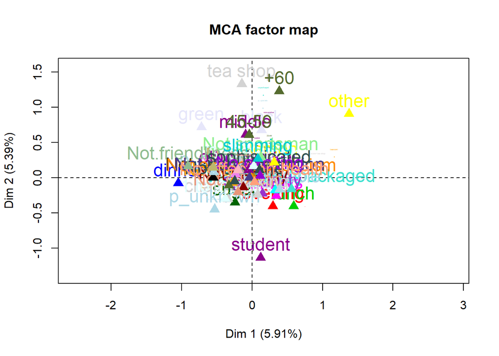

```r
# visualize MCA
plot(mca, invisible=c("ind"), graph.type = "classic", habillage = "quali", cex = c(1.5, 0.2))
```

```r
#multiple correspondence analysis for the selcected outcomes
library(FactoMineR)
mca2 <- MCA(tea_time[1:13], graph = FALSE)

# summary of the model
summary(mca2)
```

```
##
## Call:
## MCA(X = tea_time[1:13], graph = FALSE)
##
##
## Eigenvalues
##                        Dim.1   Dim.2   Dim.3   Dim.4   Dim.5   Dim.6   Dim.7
## Variance               0.168   0.109   0.098   0.092   0.087   0.083   0.078
## % of var.             13.631   8.816   7.986   7.498   7.098   6.703   6.332
## Cumulative % of var.  13.631  22.446  30.432  37.930  45.028  51.731  58.063
##                        Dim.8   Dim.9  Dim.10  Dim.11  Dim.12  Dim.13  Dim.14
## Variance               0.077   0.069   0.065   0.060   0.058   0.052   0.050
## % of var.              6.266   5.597   5.318   4.899   4.696   4.212   4.068
## Cumulative % of var.  64.329  69.926  75.244  80.143  84.839  89.051  93.118
##                       Dim.15  Dim.16
## Variance               0.044   0.041
## % of var.              3.544   3.338
## Cumulative % of var.  96.662 100.000
##
## Individuals (the 10 first)
##                 Dim.1    ctr   cos2    Dim.2    ctr   cos2    Dim.3    ctr
## 1            | -0.582  0.674  0.471 |  0.311  0.298  0.134 | -0.080  0.022
## 2            | -0.538  0.574  0.298 |  0.418  0.537  0.181 | -0.359  0.438
## 3            |  0.209  0.087  0.024 |  0.014  0.001  0.000 |  0.471  0.751
## 4            | -0.750  1.118  0.364 |  0.048  0.007  0.001 |  0.583  1.151
## 5            | -0.297  0.175  0.119 | -0.289  0.257  0.113 |  0.080  0.022
## 6            | -0.750  1.118  0.364 |  0.048  0.007  0.001 |  0.583  1.151
## 7            | -0.140  0.039  0.051 | -0.048  0.007  0.006 | -0.062  0.013
## 8            | -0.220  0.096  0.047 |  0.448  0.617  0.194 | -0.582  1.148
## 9            | -0.314  0.195  0.134 |  0.144  0.064  0.028 | -0.365  0.452
## 10           | -0.191  0.073  0.032 |  0.426  0.556  0.160 | -0.066  0.015
##                cos2
## 1             0.009 |
## 2             0.133 |
## 3             0.120 |
## 4             0.220 |
## 5             0.009 |
## 6             0.220 |
## 7             0.010 |
## 8             0.327 |
```

[output cut: 24 more lines]

```
## always        0.203  1.107  0.022  2.537 |
## Not.always   -0.106  0.579  0.022 -2.537 |
##
## Categorical variables (eta2)
##                Dim.1 Dim.2 Dim.3
## tea.time     | 0.240 0.043 0.100 |
## evening      | 0.111 0.019 0.016 |
## lunch        | 0.097 0.068 0.182 |
## dinner       | 0.078 0.014 0.283 |
## always       | 0.085 0.107 0.022 |
## home         | 0.000 0.060 0.083 |
## work         | 0.189 0.029 0.001 |
## tearoom      | 0.296 0.095 0.017 |
## friends      | 0.307 0.030 0.002 |
## resto        | 0.325 0.042 0.016 |
```

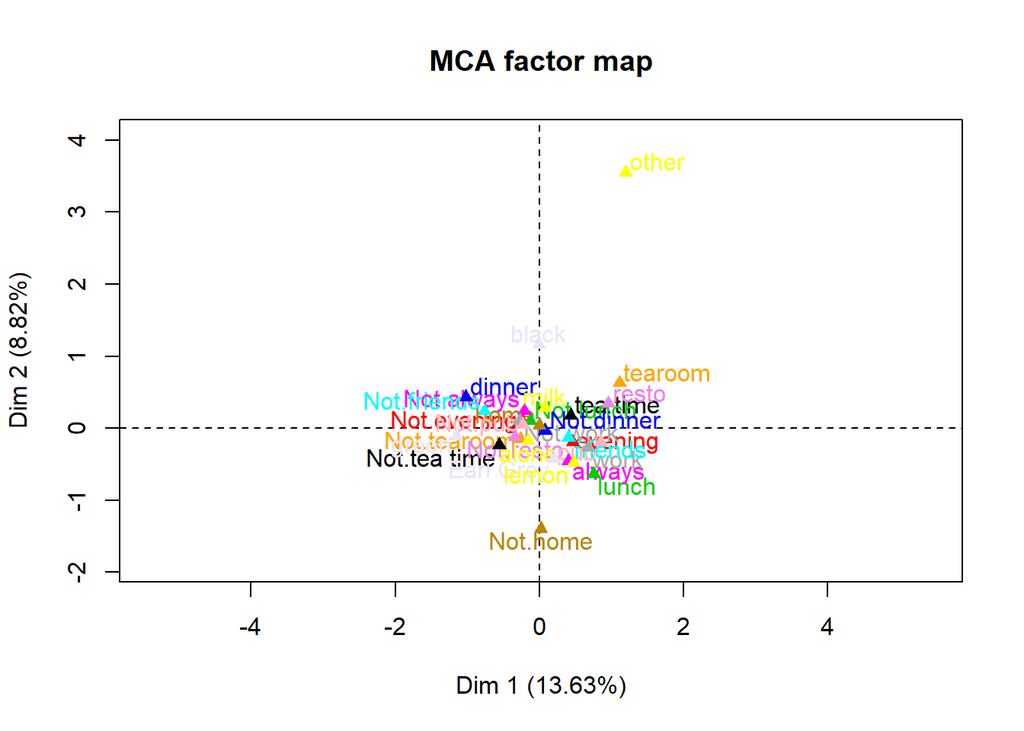

```r
# visualize MCA
plot(mca2, invisible=c("ind"), graph.type = "classic", habillage = "quali")
```

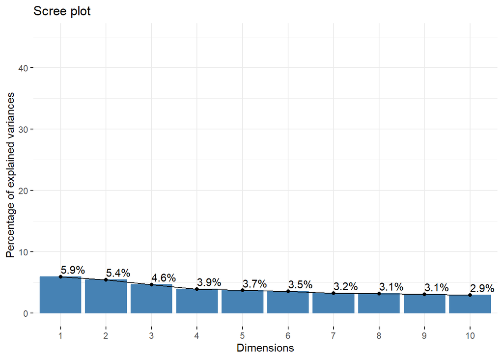

```r
install.packages("ggplot2")
library(ggplot2)
library(factoextra)
#to visualize the percentages of inertia explained by each MCA dimensions,
fviz_screeplot(mca, addlabels = TRUE, ylim = c(0, 45))
```

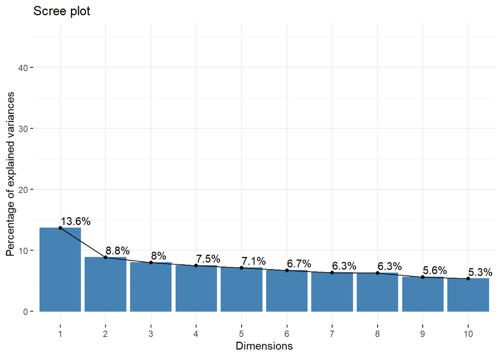

```r
fviz_screeplot(mca2, addlabels = TRUE, ylim = c(0, 45))
```

The Multiple Correspondence Analysis (MCA) on the total tea data (mca) and for the selected variables are presented above as well as biplots and plots to visualize the percentages of inertia explained by each MCA dimensions.